# DIA 2. GLM

Facundo X. Palacio

2022-03-09

### PRESENCIA-AUSENCIA

Cabral et al. (2007) estudiaron la distribución de platijas (*Solea solea*) en el estuario Tagus, Portugal. Se desea saber qué factores están relacionados con la presencia esta especie.

```r
# Analisis exploratorio
datos <- read.table("C:/RD/Solea.txt", header = TRUE)
str(datos)
```

```
## 'data.frame':    65 obs. of  13 variables:
##  $ Sample       : int  1 2 3 4 5 6 7 8 9 10 ...
##  $ season       : int  1 1 1 1 1 1 1 1 1 1 ...
##  $ month        : int  5 5 5 5 5 5 5 5 5 5 ...
##  $ Area         : int  2 2 2 4 4 4 3 3 3 1 ...
##  $ depth        : num  3 2.6 2.6 2.1 3.2 3.5 1.6 1.7 1.8 4.5 ...
##  $ temperature  : int  20 18 19 20 20 20 19 17 19 21 ...
##  $ salinity     : int  30 29 30 29 30 32 29 28 29 12 ...
##  $ transparency : int  15 15 15 15 15 7 15 10 10 35 ...
##  $ gravel       : num  3.74 1.94 2.88 11.06 9.87 ...
##  $ large_sand   : num  13.15 4.99 8.98 11.96 28.6 ...
##  $ med_fine_sand: num  11.93 5.43 16.85 21.95 19.49 ...
##  $ mud          : num  71.2 87.6 71.3 55 42 ...
##  $ Solea_solea  : int  0 0 1 0 0 0 1 1 0 1 ...
```

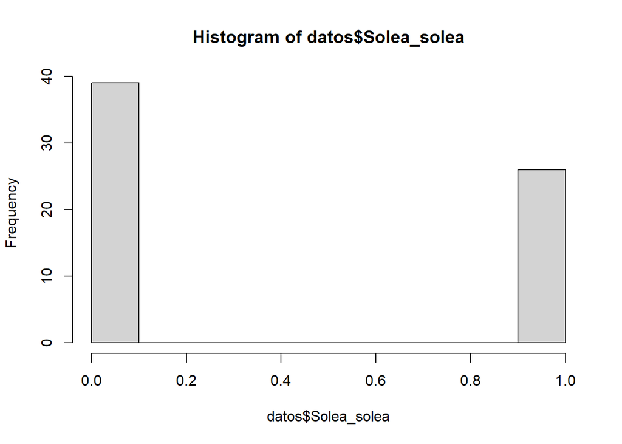

```r
hist(datos$Solea_solea)
```

```r
table(datos$Solea_solea)
```

```
##
##  0  1
## 39 26
```

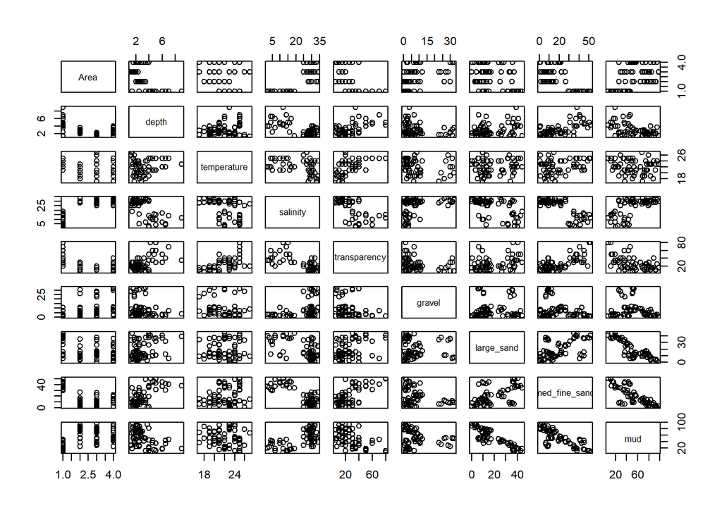

```r
pairs(datos[, 4:12])
```

```r
round(cor(datos[, 4:12]), 2)
```

```
##                Area depth temperature salinity transparency gravel large_sand
## Area           1.00 -0.55       -0.18     0.76        -0.56   0.44      -0.44
## depth         -0.55  1.00        0.14    -0.66         0.57  -0.24       0.31
## temperature   -0.18  0.14        1.00    -0.35         0.54  -0.16       0.12
## salinity       0.76 -0.66       -0.35     1.00        -0.66   0.38      -0.54
## transparency  -0.56  0.57        0.54    -0.66         1.00  -0.25       0.37
## gravel         0.44 -0.24       -0.16     0.38        -0.25   1.00       0.01
## large_sand    -0.44  0.31        0.12    -0.54         0.37   0.01       1.00
## med_fine_sand -0.69  0.67        0.25    -0.80         0.69  -0.32       0.56
## mud            0.49 -0.47       -0.16     0.63        -0.52  -0.19      -0.87
##               med_fine_sand   mud
## Area                  -0.69  0.49
## depth                  0.67 -0.47
## temperature            0.25 -0.16
## salinity              -0.80  0.63
## transparency           0.69 -0.52
## gravel                -0.32 -0.19
## large_sand             0.56 -0.87
## med_fine_sand          1.00 -0.78
## mud                   -0.78  1.00
```

### GLM binomial

```r
m.bin <- glm(Solea_solea ~ temperature + transparency + salinity, family = binomial, data = datos)
summary(m.bin)
```

```
##
## Call:
## glm(formula = Solea_solea ~ temperature + transparency + salinity,
##     family = binomial, data = datos)
##
## Deviance Residuals:
##     Min       1Q   Median       3Q      Max
## -2.2170  -0.7607  -0.6364   0.7219   1.8447
##
## Coefficients:
##               Estimate Std. Error z value Pr(>|z|)
## (Intercept)   5.221629   3.524358   1.482  0.13845
## temperature  -0.100542   0.148829  -0.676  0.49932
## transparency -0.001162   0.025347  -0.046  0.96343
## salinity     -0.142652   0.049986  -2.854  0.00432 **
## ---
## Signif. codes:  0 '***' 0.001 '**' 0.01 '*' 0.05 '.' 0.1 ' ' 1
##
## (Dispersion parameter for binomial family taken to be 1)
##
##     Null deviance: 87.492  on 64  degrees of freedom
## Residual deviance: 67.973  on 61  degrees of freedom
## AIC: 75.973
##
## Number of Fisher Scoring iterations: 4
```

### Bondad del ajuste

```r
summary(m.bin)
```

```
##
## Call:
## glm(formula = Solea_solea ~ temperature + transparency + salinity,
##     family = binomial, data = datos)
##
## Deviance Residuals:
##     Min       1Q   Median       3Q      Max
## -2.2170  -0.7607  -0.6364   0.7219   1.8447
##
## Coefficients:
##               Estimate Std. Error z value Pr(>|z|)
## (Intercept)   5.221629   3.524358   1.482  0.13845
## temperature  -0.100542   0.148829  -0.676  0.49932
## transparency -0.001162   0.025347  -0.046  0.96343
## salinity     -0.142652   0.049986  -2.854  0.00432 **
## ---
## Signif. codes:  0 '***' 0.001 '**' 0.01 '*' 0.05 '.' 0.1 ' ' 1
##
## (Dispersion parameter for binomial family taken to be 1)
##
##     Null deviance: 87.492  on 64  degrees of freedom
## Residual deviance: 67.973  on 61  degrees of freedom
## AIC: 75.973
##
## Number of Fisher Scoring iterations: 4
```

```r
1 - (m.bin$dev/m.bin$null) # Pseudo-R2
```

```
## [1] 0.2230856
```

```r
library(performance)
r2_tjur(m.bin) # Coeficiente de determinacion de Tjur
```

```
## Tjur's R2
## 0.2840808
```

### Grafico del modelo

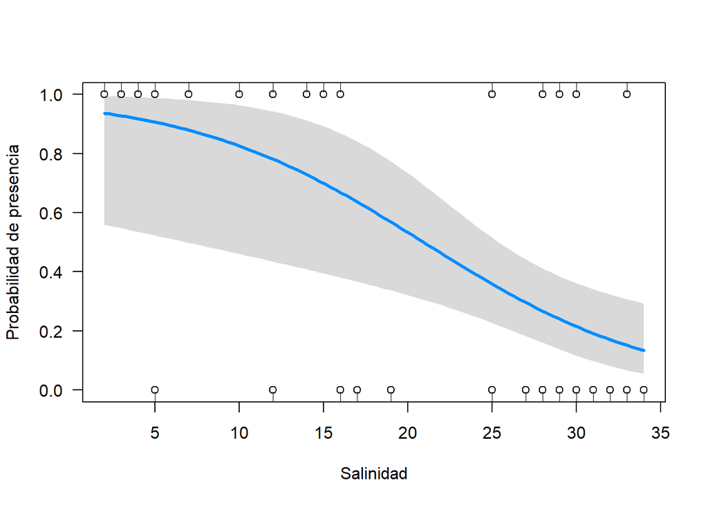

```r
library(visreg)
visreg(fit = m.bin, xvar = "salinity", scale = "response", ylim = c(0, 1),
       xlab = "Salinidad", ylab = "Probabilidad de presencia")
points(datos$salinity, datos$Solea_solea)
```

### Interpretacion de los coeficientes

```r
exp(m.bin$coeff[2]) # Razon de odds
```

```
## temperature
##   0.9043472
```

#### Validacion

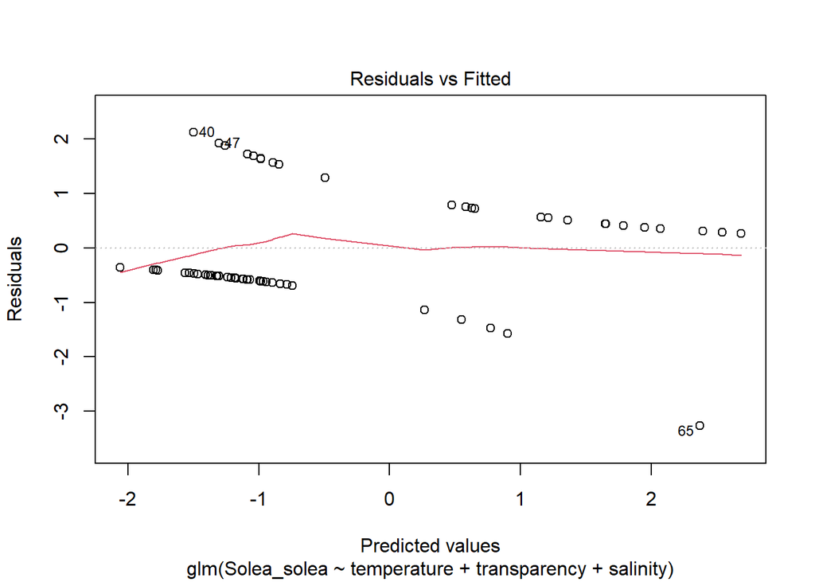

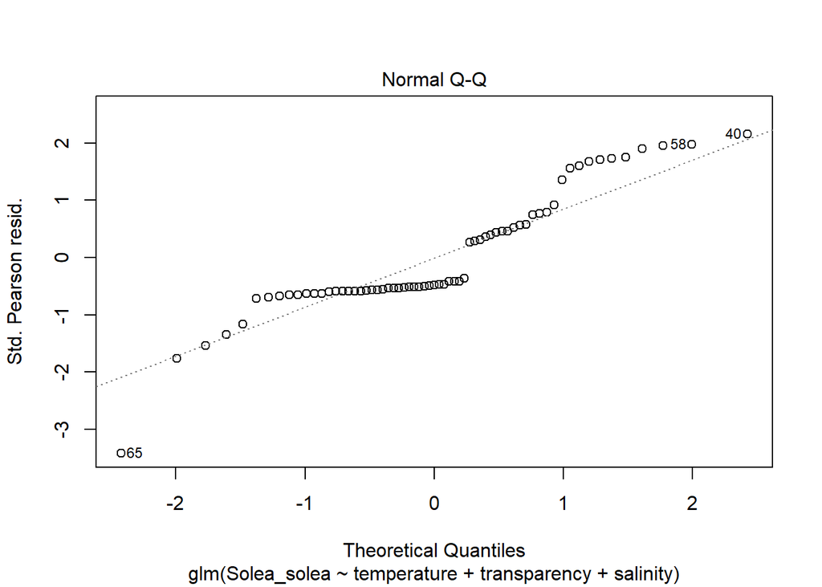

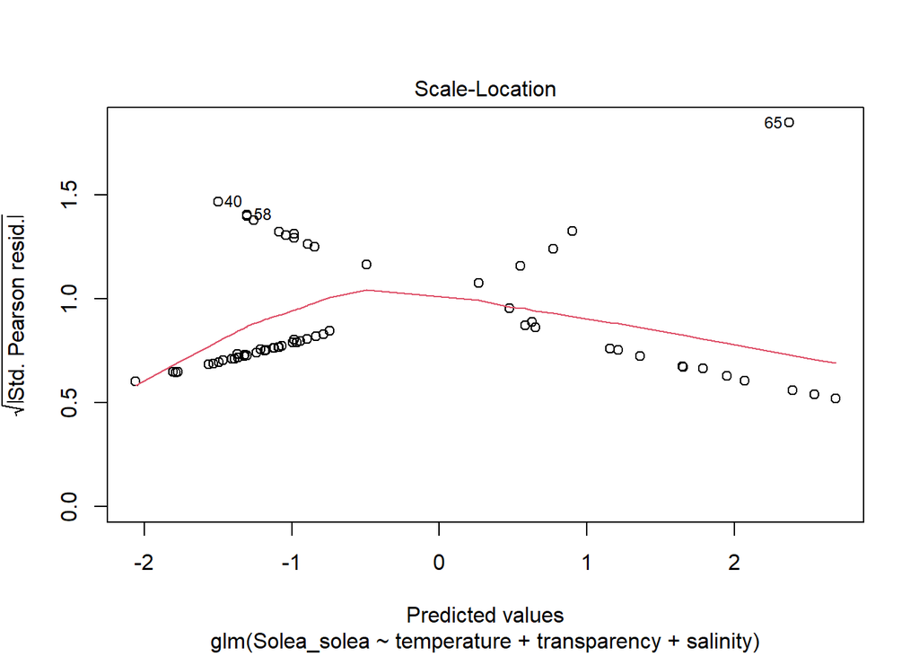

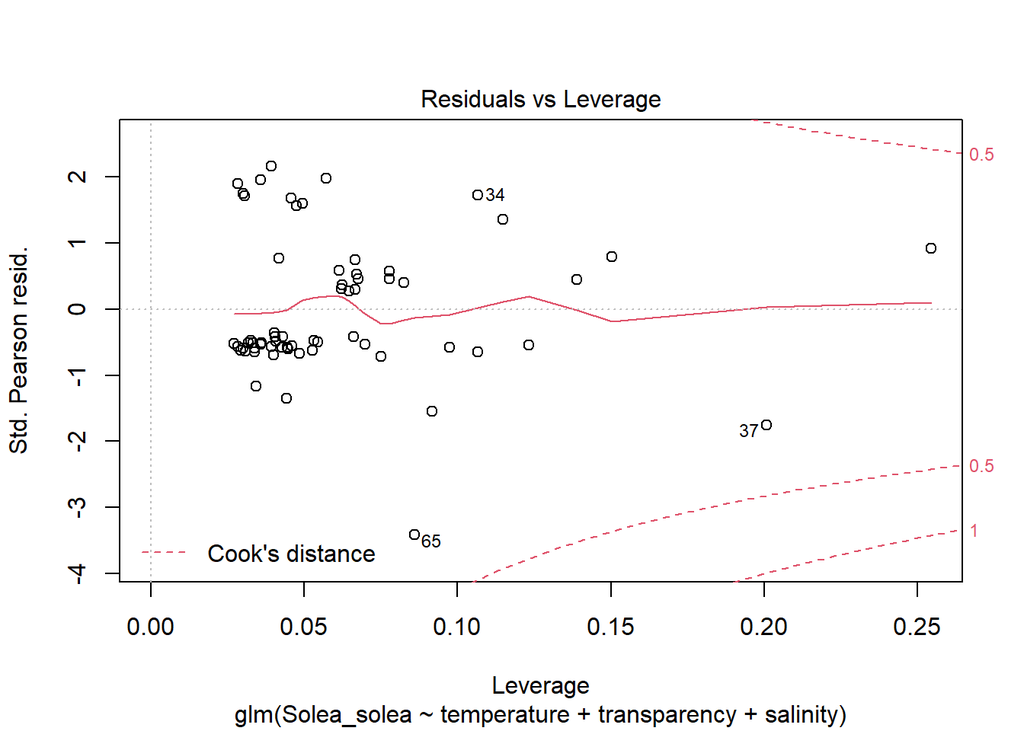

```r
plot(m.bin)
```

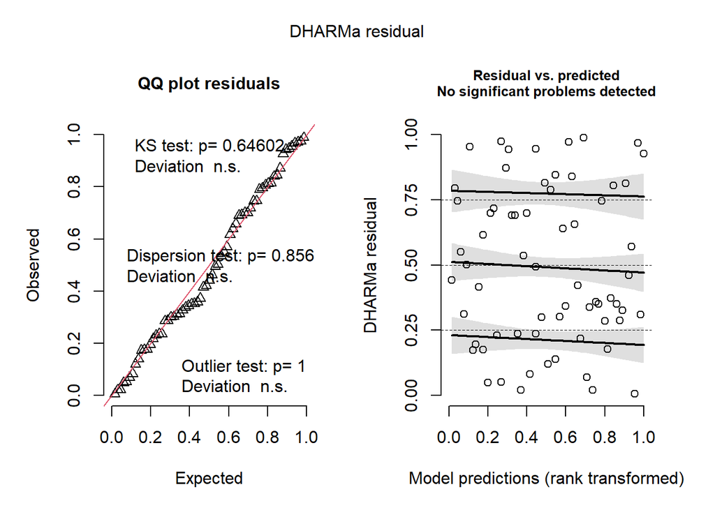

```r
library(DHARMa)
plot(simulateResiduals(fittedModel = m.bin))
```

#### Ecuacion

```r
library(equatiomatic)
extract_eq(m.bin, use_coefs = TRUE, fix_signs = TRUE)
```

$$\log\left[ \frac { \widehat{P( \operatorname{Solea\_solea} = \operatorname{1} )} }{ 1 - \widehat{P( \operatorname{Solea\_solea} = \operatorname{1} )} } \right] = 5.22 - 0.1(\operatorname{temperature}) + 0(\operatorname{transparency}) - 0.14(\operatorname{salinity})$$

### Capacidad predictiva

```r
# Matriz de confusion
obs <- datos$Solea_solea
pred <- ifelse(predict(m.bin, type = "response")>0.5, 1, 0)
matriz.conf <- table(obs, pred)
matriz.conf
```

```
##    pred
## obs  0  1
##   0 34  5
##   1 11 15
```

```r
# Porcentajes de clasificacion
matriz.conf/rowSums(matriz.conf)
```

```
##    pred
## obs         0         1
##   0 0.8717949 0.1282051
##   1 0.4230769 0.5769231
```

### CONTEOS

Gotelli & Ellison (2002) analizaron los determinantes biogeográficos de la riqueza de hormigas (Srich) a escala regional (hormigas.txt). Para esto se describió el tipo de hábitat (Habitat), la latitud (Latitude) y la altitud (Elevation).

```r
# Analisis exploratorio
h <- read.table("C:/RD/hormigas.txt", header = T)
str(h)
```

```
## 'data.frame':    44 obs. of  5 variables:
##  $ Site     : chr  "TPB" "HBC" "CKB" "SKP" ...
##  $ Srich    : int  6 16 18 17 9 15 7 12 14 9 ...
##  $ Habitat  : chr  "Forest" "Forest" "Forest" "Forest" ...
##  $ Latitude : num  42 42 42 42 42 ...
##  $ Elevation: int  389 8 152 1 210 78 47 491 121 95 ...
```

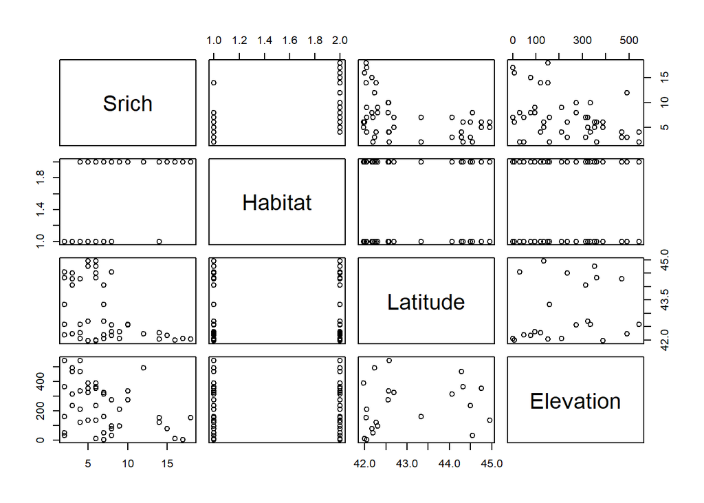

```r
h$Habitat <- as.factor(h$Habitat)
pairs(h[, 2:5])
```

```r
round(cor(h[, c(2, 4:5)]), 2)
```

```
##           Srich Latitude Elevation
## Srich      1.00    -0.44     -0.38
## Latitude  -0.44     1.00      0.18
## Elevation -0.38     0.18      1.00
```

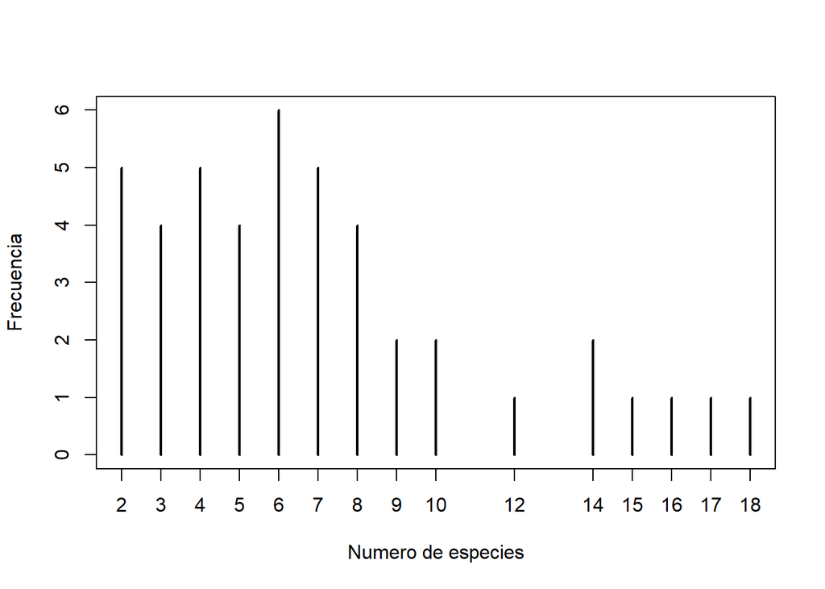

```r
plot(table(h$Srich), xlab = "Numero de especies", ylab = "Frecuencia")
```

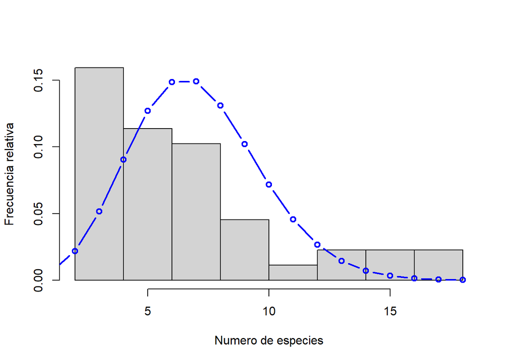

```r
hist(h$Srich, xlab = "Numero de especies", ylab = "Frecuencia relativa", main = "", freq = FALSE)
# Ajuste de distribucion a los datos
sim.pois <- dpois(x = 0:max(h$Srich), lambda = mean(h$Srich))
lines(x = 0:max(h$Srich), y = sim.pois, col = "blue", lwd = 2, type = "b")
```

```r
var(h$Srich)/mean(h$Srich)
```

```
## [1] 2.566343
```

### GLM Poisson

```r
m.pois <- glm(Srich ~ Latitude + Elevation + Habitat, family = poisson, data = h)
summary(m.pois)
```

```
##
## Call:
## glm(formula = Srich ~ Latitude + Elevation + Habitat, family = poisson,
##     data = h)
##
## Deviance Residuals:
##      Min        1Q    Median        3Q       Max
## -2.20939  -0.72643  -0.05933   0.51571   2.60147
##
## Coefficients:
##                 Estimate Std. Error z value Pr(>|z|)
## (Intercept)   11.9368121  2.6214970   4.553 5.28e-06 ***
## Latitude      -0.2357930  0.0616638  -3.824 0.000131 ***
## Elevation     -0.0011411  0.0003749  -3.044 0.002337 **
## HabitatForest  0.6354389  0.1195664   5.315 1.07e-07 ***
## ---
## Signif. codes:  0 '***' 0.001 '**' 0.01 '*' 0.05 '.' 0.1 ' ' 1
##
## (Dispersion parameter for poisson family taken to be 1)
##
##     Null deviance: 102.76  on 43  degrees of freedom
## Residual deviance:  40.69  on 40  degrees of freedom
## AIC: 209.04
##
## Number of Fisher Scoring iterations: 4
```

### GLM quasi-Poisson

```r
m.qpois <- glm(Srich ~ Latitude + Elevation + Habitat, family = quasipoisson, data = h)
summary(m.qpois)
```

```
##
## Call:
## glm(formula = Srich ~ Latitude + Elevation + Habitat, family = quasipoisson,
##     data = h)
##
## Deviance Residuals:
##      Min        1Q    Median        3Q       Max
## -2.20939  -0.72643  -0.05933   0.51571   2.60147
##
## Coefficients:
##                 Estimate Std. Error t value Pr(>|t|)
## (Intercept)   11.9368121  2.6594025   4.489 5.94e-05 ***
## Latitude      -0.2357930  0.0625554  -3.769 0.000529 ***
## Elevation     -0.0011411  0.0003803  -3.000 0.004626 **
## HabitatForest  0.6354389  0.1212952   5.239 5.52e-06 ***
## ---
## Signif. codes:  0 '***' 0.001 '**' 0.01 '*' 0.05 '.' 0.1 ' ' 1
##
## (Dispersion parameter for quasipoisson family taken to be 1.029128)
##
##     Null deviance: 102.76  on 43  degrees of freedom
## Residual deviance:  40.69  on 40  degrees of freedom
## AIC: NA
##
## Number of Fisher Scoring iterations: 4
```

```r
# Parámetro de dispersión
resid <- residuals(m.qpois, type = "pearson")
nparam <- length(m.qpois$coeff)
ndatos <- nrow(h)
disp.param <- sum(resid^2)/(ndatos - nparam)
disp.param
```

```
## [1] 1.029116
```

```r
m.qpois.null <- glm(Srich ~ 1, family = quasipoisson, data = h)
summary(m.qpois.null)
```

```
##
## Call:
## glm(formula = Srich ~ 1, family = quasipoisson, data = h)
##
## Deviance Residuals:
##     Min       1Q   Median       3Q      Max
## -2.2409  -1.2420  -0.3959   0.4492   3.4539
##
## Coefficients:
##             Estimate Std. Error t value Pr(>|t|)
## (Intercept)  1.94915    0.09113   21.39   <2e-16 ***
## ---
## Signif. codes:  0 '***' 0.001 '**' 0.01 '*' 0.05 '.' 0.1 ' ' 1
##
## (Dispersion parameter for quasipoisson family taken to be 2.566343)
##
##     Null deviance: 102.76  on 43  degrees of freedom
## Residual deviance: 102.76  on 43  degrees of freedom
## AIC: NA
##
## Number of Fisher Scoring iterations: 5
```

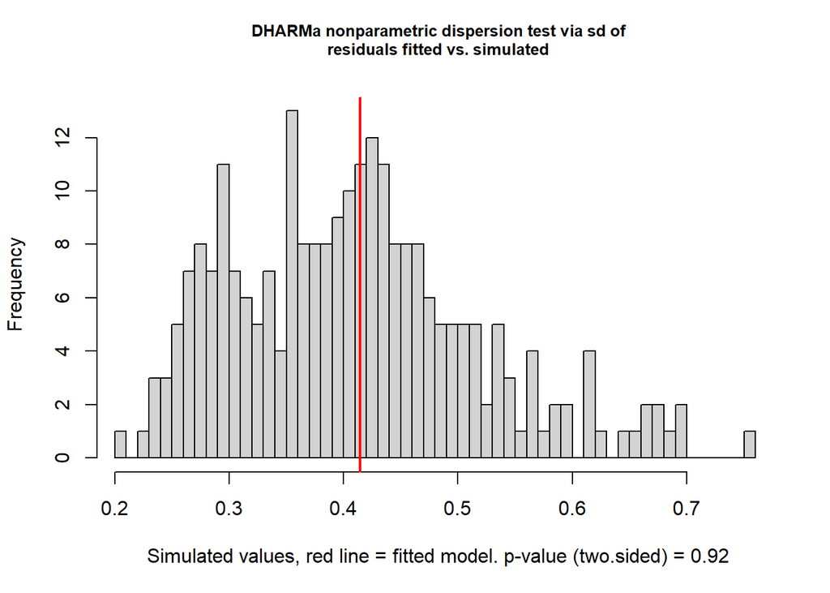

```
##
##  DHARMa nonparametric dispersion test via sd of residuals fitted vs.
##  simulated
##
## data:  simulationOutput
## dispersion = 1.0136, p-value = 0.92
## alternative hypothesis: two.sided
```

```r
library(DHARMa)
testDispersion(m.pois)
```

### Validacion

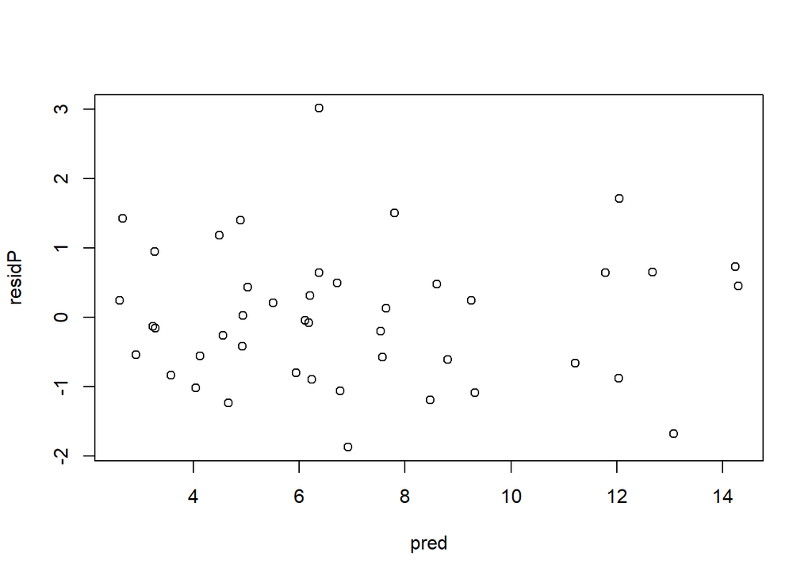

```r
residP <- resid(m.qpois, type = "pearson")  # residuos de Pearson
residD <- resid(m.qpois, type = "deviance") # residuos de devianza
pred <- predict(m.qpois, type = "response") # valores predichos
plot(pred, residP)
```

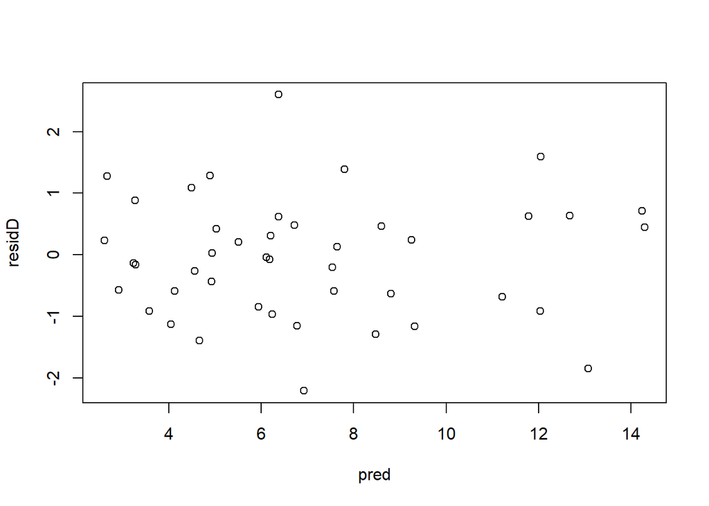

```r
plot(pred, residD)
```

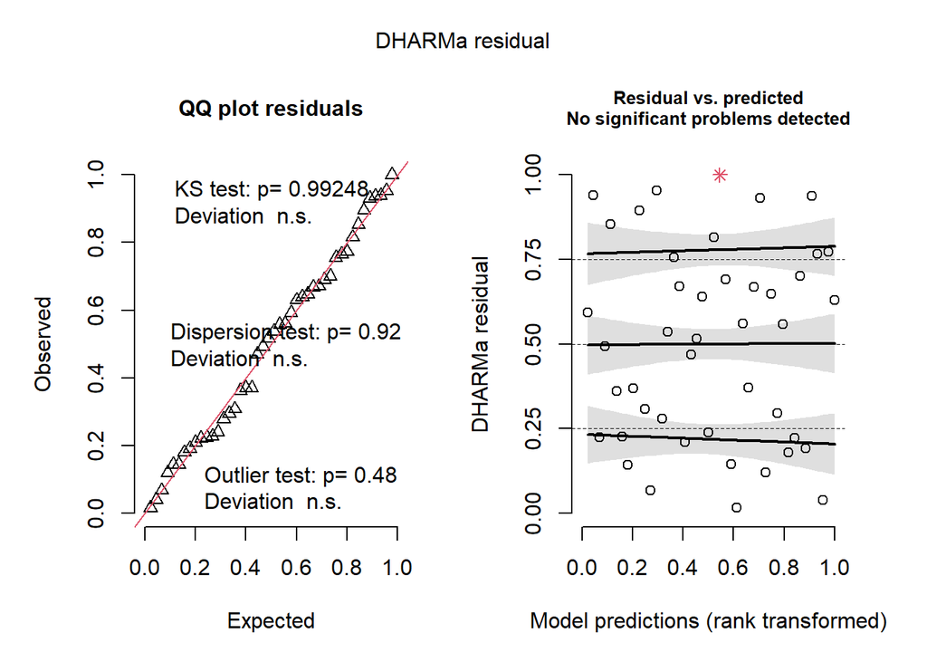

```r
plot(simulateResiduals(fittedModel = m.pois))
```

### Bondad del ajuste

```r
1 - (m.qpois$dev/m.qpois$null) # Pseudo-R2
```

```
## [1] 0.6040372
```

#### Ecuacion

```r
library(equatiomatic)
extract_eq(m.qpois, use_coefs = TRUE, fix_signs = TRUE)
```

$$\log ({ \widehat{E( \operatorname{Srich} )} }) = 11.94 - 0.24(\operatorname{Latitude}) + 0(\operatorname{Elevation}) + 0.64(\operatorname{Habitat}_{\operatorname{Forest}})$$

### Graficos

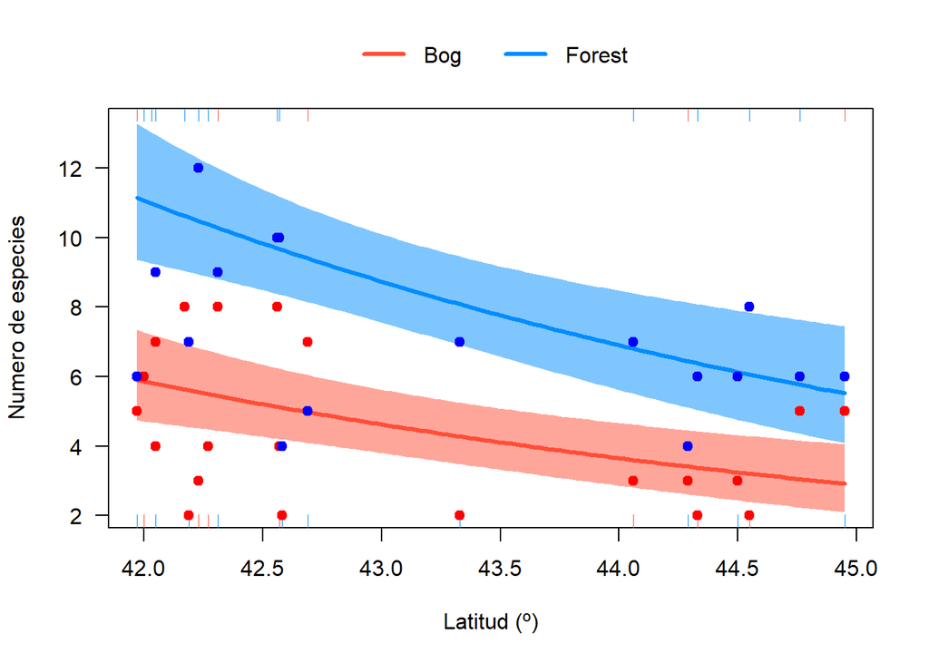

```r
library(visreg)
visreg(fit = m.qpois, xvar = "Latitude", by = "Habitat", overlay = TRUE,
       scale = "response", xlab = "Latitud (º)", ylab = "Numero de especies",
       type = "conditional", cond = list(Latitude = mean(h$Latitude), Elevation = mean(h$Elevation)))
bg <- h[h$Habitat == "Bog", ]
ft <- h[h$Habitat == "Forest", ]
points(bg$Latitude, bg$Srich, pch=19, col = "red")
points(ft$Latitude, ft$Srich, pch=19, col = "blue")
```

## GLM binomial negativo

Leong et al. (2014) estudiaron el efecto del paisaje (urbano, agrícola y natural) sobre el número de interacciones de polinizadores nativos en $Centaurea solstitialis$ (Asteraceae). Se quiere evaluar si existen diferencias en el número de interacciones (total) entre los 3 tipos de ambientes (type) teniendo en cuenta la temperatura (temp) y la velocidad del viento (wind).

```r
# Analisis exploratorio
pol <- read.table("C:/RD/bees_data.txt", header = T)
str(pol)
```

```
## 'data.frame':    36 obs. of  34 variables:
##  $ locality    : chr  "arabian" "arabian" "arabian" "bdm_f" ...
##  $ type        : chr  "a" "a" "a" "n" ...
##  $ lat         : num  37.9 37.9 37.9 38 38 ...
##  $ long        : num  -122 -122 -122 -122 -122 ...
##  $ water       : int  0 0 0 0 0 0 0 0 0 0 ...
##  $ urban       : int  18900 18900 18900 37800 37800 37800 4500 4500 4500 198000 ...
##  $ agr         : int  252000 252000 252000 0 0 0 16200 16200 16200 558000 ...
##  $ natural     : int  513900 513900 513900 747900 747900 747900 765000 765000 765000 32400 ...
##  $ bare        : int  1800 1800 1800 0 0 0 0 0 0 0 ...
##  $ bloom.cat   : int  3 3 3 3 3 3 4 4 4 4 ...
##  $ time        : chr  "am" "mid" "pm" "am" ...
##  $ wind        : num  2.7 1.35 0.8 2.3 3.75 3.7 2.4 2.15 2.5 0.85 ...
##  $ temp        : num  80.9 94.3 91.1 86.1 87.4 ...
##  $ hb          : int  70 44 24 34 24 27 40 29 14 88 ...
```

[output cut: 20 more lines]

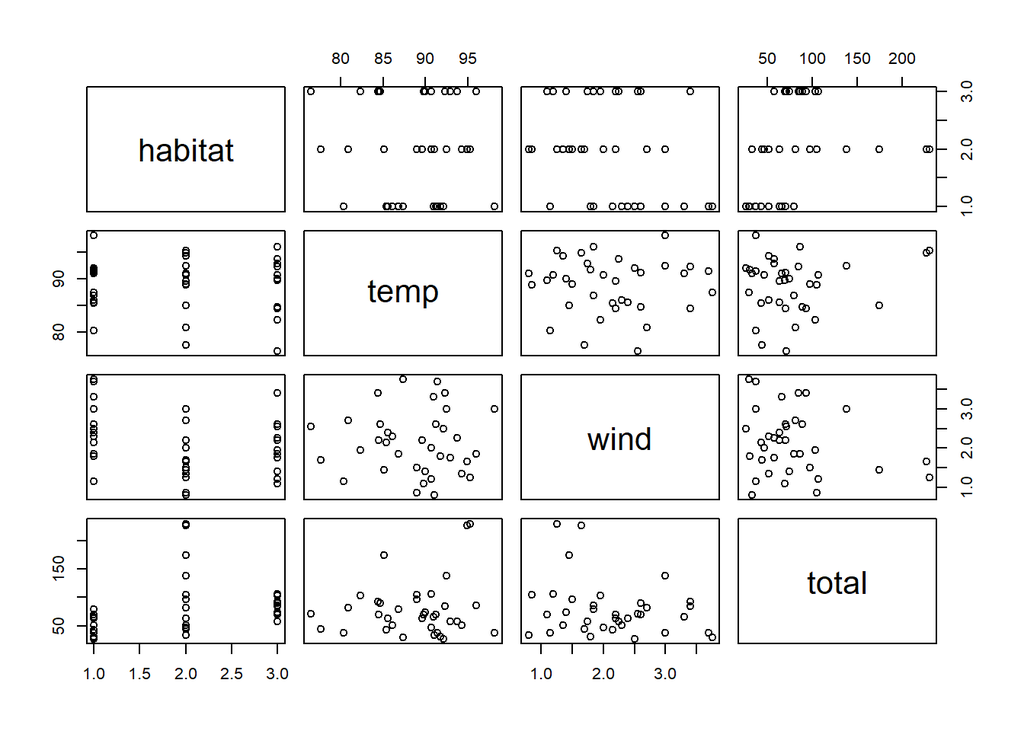

```r
pol$habitat <- factor(pol$type, levels = c("n", "a", "u"))
pairs(pol[, c("habitat", "temp", "wind", "total")])
```

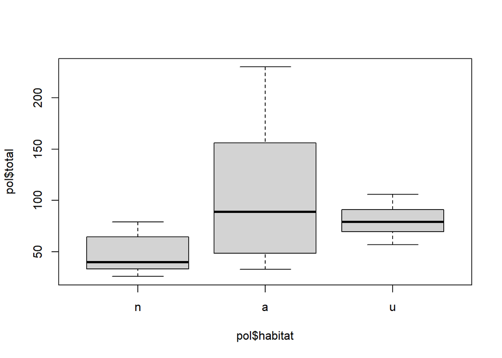

```r
boxplot(pol$total ~ pol$habitat)
```

```r
cor(pol$temp, pol$wind)
```

```
## [1] -0.02087349
```

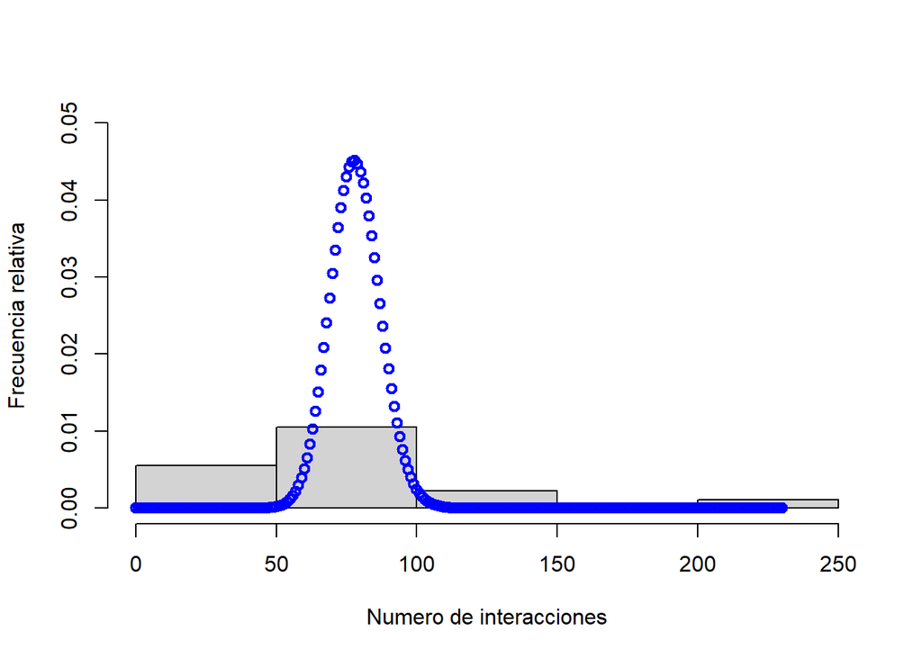

```r
hist(pol$total, xlab = "Numero de interacciones", ylab = "Frecuencia relativa", main = "", freq = FALSE, ylim = c(0, 0.05))
# Ajuste de distribucion a los datos
sim.pois <- dpois(x = 0:max(pol$total), lambda = mean(pol$total))
lines(x = 0:max(pol$total), y = sim.pois, col = "blue", lwd = 2, type = "b")
```

```r
var(pol$total)/mean(pol$total)
```

```
## [1] 30.01128
```

#### Chequear sobredispersion

```r
mqpoi.pol <- glm(total ~ habitat + temp + wind, family = quasipoisson, data = pol)
summary(mqpoi.pol)
```

```
##
## Call:
## glm(formula = total ~ habitat + temp + wind, family = quasipoisson,
##     data = pol)
##
## Deviance Residuals:
##     Min       1Q   Median       3Q      Max
## -8.7048  -2.7630  -0.5307   2.2527   8.9461
##
## Coefficients:
##              Estimate Std. Error t value Pr(>|t|)
## (Intercept)  2.244844   1.518268   1.479  0.14935
## habitata     0.813256   0.238963   3.403  0.00186 **
## habitatu     0.535908   0.233539   2.295  0.02868 *
## temp         0.018127   0.016226   1.117  0.27252
## wind        -0.001247   0.116820  -0.011  0.99155
## ---
## Signif. codes:  0 '***' 0.001 '**' 0.01 '*' 0.05 '.' 0.1 ' ' 1
##
## (Dispersion parameter for quasipoisson family taken to be 18.37662)
##
##     Null deviance: 876.87  on 35  degrees of freedom
## Residual deviance: 565.09  on 31  degrees of freedom
## AIC: NA
##
## Number of Fisher Scoring iterations: 5
```

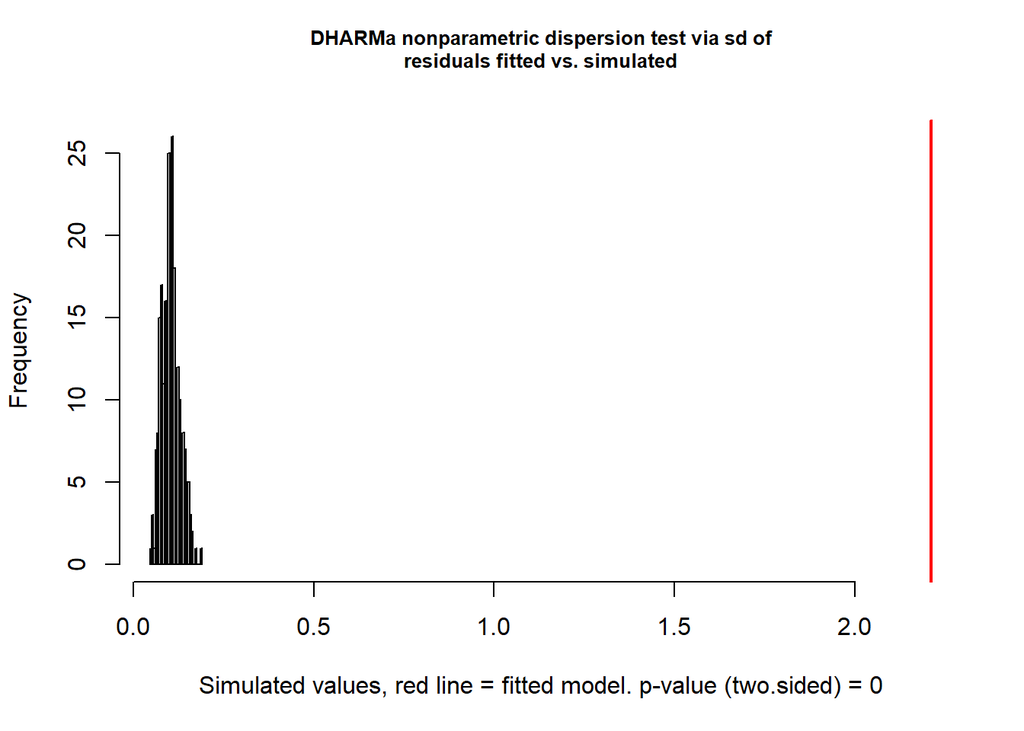

```
##
##  DHARMa nonparametric dispersion test via sd of residuals fitted vs.
##  simulated
##
## data:  simulationOutput
## dispersion = 21.413, p-value < 2.2e-16
## alternative hypothesis: two.sided
```

```r
library(DHARMa)
mpoi.pol <- glm(total ~ habitat + temp + wind, family = poisson, data = pol)
testDispersion(mpoi.pol)
```

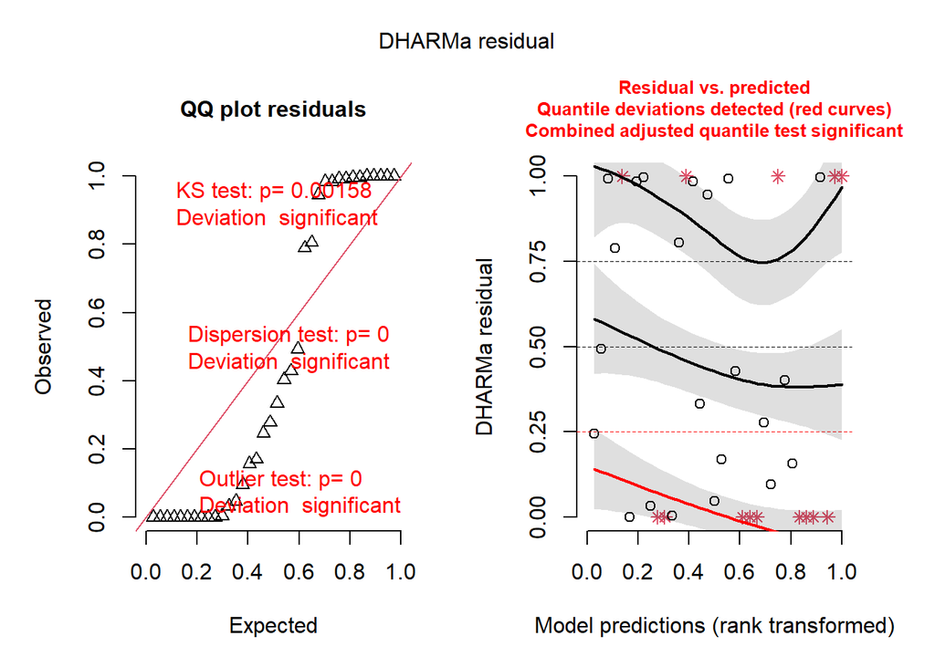

```r
plot(simulateResiduals(fittedModel = mpoi.pol))
```

#### Modelo binomial negativo

```r
library(MASS)
mbn.pol <- glm.nb(total ~ habitat + temp + wind, data = pol)
summary(mbn.pol)
```

```
##
## Call:
## glm.nb(formula = total ~ habitat + temp + wind, data = pol, init.theta = 5.957692263,
##     link = log)
##
## Deviance Residuals:
##     Min       1Q   Median       3Q      Max
## -2.3561  -0.8982  -0.1773   0.5760   1.8680
##
## Coefficients:
##             Estimate Std. Error z value Pr(>|z|)
## (Intercept)  2.82455    1.28889   2.191  0.02842 *
## habitata     0.78487    0.19397   4.046  5.2e-05 ***
## habitatu     0.52773    0.18051   2.924  0.00346 **
## temp         0.01218    0.01406   0.866  0.38652
## wind        -0.01878    0.10041  -0.187  0.85161
## ---
## Signif. codes:  0 '***' 0.001 '**' 0.01 '*' 0.05 '.' 0.1 ' ' 1
##
## (Dispersion parameter for Negative Binomial(5.9577) family taken to be 1)
##
##     Null deviance: 58.860  on 35  degrees of freedom
## Residual deviance: 36.513  on 31  degrees of freedom
## AIC: 358.06
##
## Number of Fisher Scoring iterations: 1
##
##
##               Theta:  5.96
##           Std. Err.:  1.47
##
##  2 x log-likelihood:  -346.062
```

#### Validacion del modelo binomial negativo

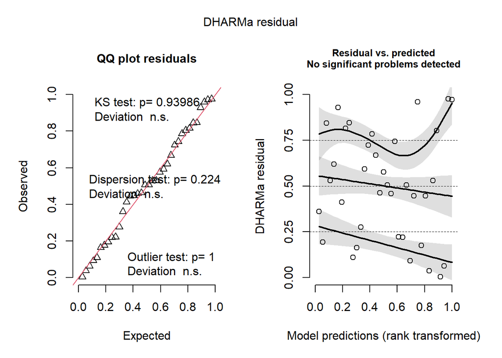

```r
plot(simulateResiduals(fittedModel = mbn.pol))
```

### Bondad del ajuste

```r
1 - (mbn.pol$dev/mbn.pol$null) # Pseudo-R2
```

```
## [1] 0.3796712
```

#### Ecuacion

```r
library(equatiomatic)
extract_eq(mbn.pol, use_coefs = TRUE, fix_signs = TRUE)
```

$$\log ({ \widehat{E( \operatorname{total} )} }) = 2.82 + 0.78(\operatorname{habitat}_{\operatorname{a}}) + 0.53(\operatorname{habitat}_{\operatorname{u}}) + 0.01(\operatorname{temp}) - 0.02(\operatorname{wind})$$

#### Comparaciones multiples

```r
library(multcomp)
comp <- glht(mbn.pol, mcp(habitat = "Tukey"))
summary(comp)
```

```
##
##   Simultaneous Tests for General Linear Hypotheses
##
## Multiple Comparisons of Means: Tukey Contrasts
##
##
## Fit: glm.nb(formula = total ~ habitat + temp + wind, data = pol, init.theta = 5.957692263,
##     link = log)
##
## Linear Hypotheses:
##            Estimate Std. Error z value Pr(>|z|)
## a - n == 0   0.7849     0.1940   4.046  < 0.001 ***
## u - n == 0   0.5277     0.1805   2.924  0.00982 **
## u - a == 0  -0.2571     0.1785  -1.441  0.31956
## ---
## Signif. codes:  0 '***' 0.001 '**' 0.01 '*' 0.05 '.' 0.1 ' ' 1
## (Adjusted p values reported -- single-step method)
```

### Incluyendo un offset

```r
mbn.pol.off <- glm.nb(total ~ habitat + temp + wind + offset(log(min)), data = pol)
summary(mbn.pol.off)
```

```
##
## Call:
## glm.nb(formula = total ~ habitat + temp + wind + offset(log(min)),
##     data = pol, init.theta = 5.957692263, link = log)
##
## Deviance Residuals:
##     Min       1Q   Median       3Q      Max
## -2.3561  -0.8982  -0.1773   0.5760   1.8680
##
## Coefficients:
##             Estimate Std. Error z value Pr(>|z|)
## (Intercept) -1.67526    1.28889  -1.300  0.19368
## habitata     0.78487    0.19397   4.046  5.2e-05 ***
## habitatu     0.52773    0.18051   2.924  0.00346 **
## temp         0.01218    0.01406   0.866  0.38652
## wind        -0.01878    0.10041  -0.187  0.85161
## ---
## Signif. codes:  0 '***' 0.001 '**' 0.01 '*' 0.05 '.' 0.1 ' ' 1
##
## (Dispersion parameter for Negative Binomial(5.9577) family taken to be 1)
##
##     Null deviance: 58.860  on 35  degrees of freedom
## Residual deviance: 36.513  on 31  degrees of freedom
## AIC: 358.06
##
## Number of Fisher Scoring iterations: 1
##
##
##               Theta:  5.96
##           Std. Err.:  1.47
##
##  2 x log-likelihood:  -346.062
```

#### Graficos

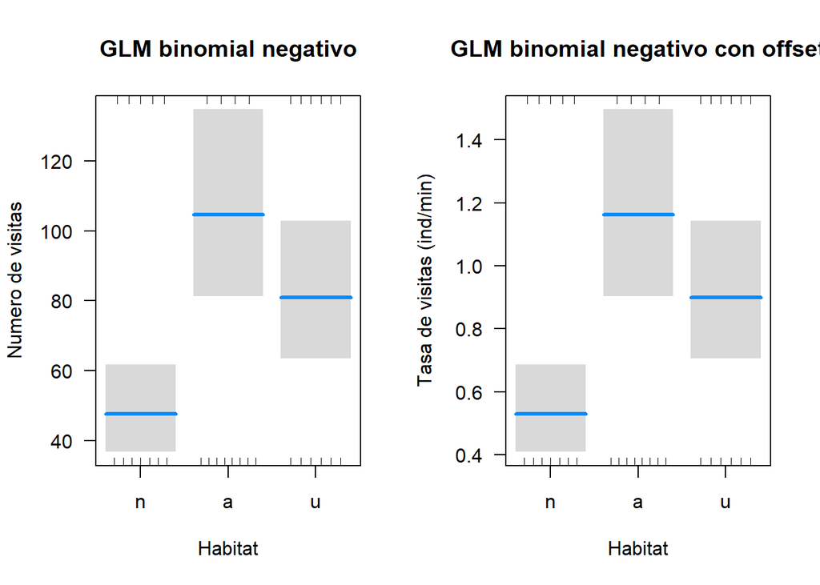

```r
layout(matrix(1:2, 1, 2))
visreg(fit = mbn.pol, xvar = "habitat", scale = "response", cond = list(temp = mean(pol$temp), wind = mean(pol$wind)), xlab = "Habitat", ylab = "Numero de visitas", main = "GLM binomial negativo")
visreg(fit = mbn.pol.off, xvar = "habitat", scale = "response", cond = list(temp = mean(pol$temp), wind = mean(pol$wind), min = 1), xlab = "Habitat", ylab = "Tasa de visitas (ind/min)", main = "GLM binomial negativo con offset")
```

```r
layout(1)
```

## Modelo lineal general

Palacio et al. (2014) estudiaron la seleccion natural mediada por aves frugivoras sobre rasgos de los frutos de *Celtis tala* (frutos Celtis 2013.txt), incluyendo el diametro (diam), peso (peso), concentracion de azucares (az), peso de pulpa (pulpa), peso de semilla (sem) y relacion peso de pulpa/peso de semilla (pulpa.sem). Analizar qué factores explican el tamaño del fruto.

```r
celtis <- read.delim("C:/RD/frutos Celtis 2013.csv", sep = ",")
str(celtis)
```

```
## 'data.frame':    617 obs. of  8 variables:
##  $ planta   : chr  "P1-10" "P1-10" "P1-10" "P1-10" ...
##  $ año      : int  2013 2013 2013 2013 2013 2013 2013 2013 2013 2013 ...
##  $ diam     : num  9.26 8.12 9.01 8.57 7.48 ...
##  $ peso     : num  0.414 0.291 0.387 0.339 0.222 0.307 0.318 0.35 0.259 0.294 ...
##  $ az       : num  18.5 21.5 18.5 23.5 16.5 ...
##  $ pulpa    : num  0.361 0.252 0.331 0.287 0.177 0.252 0.272 0.292 0.217 0.253 ...
##  $ sem      : num  0.0523 0.0393 0.0556 0.0519 0.0443 0.0555 0.0453 0.0581 0.0419 0.0417 ...
##  $ pulpa.sem: num  6.91 6.41 5.96 5.53 4 ...
```

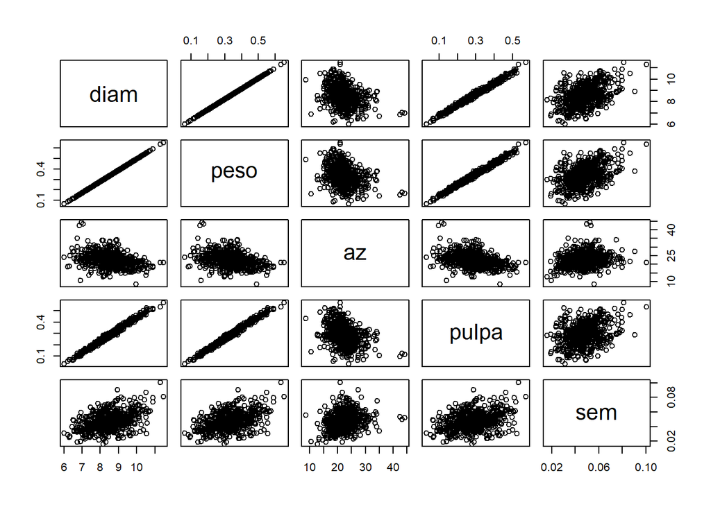

```r
pairs(celtis[, 3:7])
```

```r
round(cor(celtis[, 4:7], use = "complete.obs"), 2)
```

```
##        peso    az pulpa  sem
## peso   1.00 -0.33  0.99 0.45
## az    -0.33  1.00 -0.37 0.20
## pulpa  0.99 -0.37  1.00 0.34
## sem    0.45  0.20  0.34 1.00
```

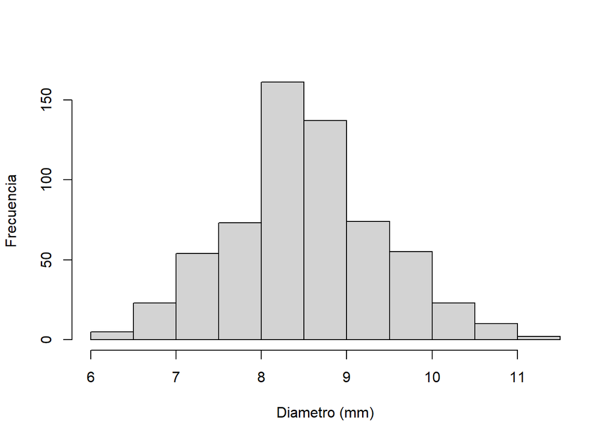

```r
hist(celtis$diam, xlab = "Diametro (mm)", ylab = "Frecuencia", main = "")
```

```r
mlg <- glm(diam ~ az + sem, family = gaussian, data = celtis)
summary(mlg)
```

```
##
## Call:
## glm(formula = diam ~ az + sem, family = gaussian, data = celtis)
##
## Deviance Residuals:
##      Min        1Q    Median        3Q       Max
## -1.96247  -0.49375  -0.01025   0.46537   2.04017
##
## Coefficients:
##              Estimate Std. Error t value Pr(>|t|)
## (Intercept)  8.750071   0.176681   49.52   <2e-16 ***
## az          -0.094204   0.006975  -13.51   <2e-16 ***
## sem         39.834317   2.400758   16.59   <2e-16 ***
## ---
## Signif. codes:  0 '***' 0.001 '**' 0.01 '*' 0.05 '.' 0.1 ' ' 1
##
## (Dispersion parameter for gaussian family taken to be 0.4902039)
##
##     Null deviance: 487.54  on 613  degrees of freedom
## Residual deviance: 299.51  on 611  degrees of freedom
##   (3 observations deleted due to missingness)
## AIC: 1309.7
##
## Number of Fisher Scoring iterations: 2
```

## Modelos truncados en cero

Santos et al. (2011) estudiaron la probabilidad de persistencia de las caracasas de animales muertos en ruta (Snakes.txt). La variable respuesta es el número de dias que perduraban las carcasas sin ser removidas (N_days). Las variables explicatorias son el tamaño de cada especie (Size_cm), la proporcion de dias con lluvia (PDayRain), las precipitaciones totales (Tot_Rain), la temperatura diaria promedio (Temp_avg), la identidad de la ruta que representa la intesidad del trafico (Road; EN114 tiene alto transito, EN4 tiene trafico medio, y EN370_EN114_4 tiene bajo trafico), la ubicación en la ruta (Road_Loc; L = asfalto, V = borde), la estacion (Season), y la especie (Species).

```r
# Analisis exploratorio
serp <- read.table("C:/RD/Snakes.txt", header = T)
str(serp)
```

```
## 'data.frame':    130 obs. of  11 variables:
##  $ ID      : int  2176 2448 2917 2927 2845 2849 2860 2760 2758 2764 ...
##  $ Road    : chr  "EN114" "EN114" "EN114" "EN114" ...
##  $ Month   : chr  "Jul" "Aug" "Oct" "Oct" ...
##  $ Season  : chr  "Summer" "Summer" "Autumn" "Autumn" ...
##  $ N_days  : int  4 1 4 2 1 1 2 1 2 2 ...
##  $ Species : chr  "Coluberhippocrepis" "Elaphescalaris" "Elaphescalaris" "Elaphescalaris" ...
##  $ Road_Loc: chr  "L" "L" "L" "L" ...
##  $ Size_cm : int  115 150 150 150 150 150 150 150 150 150 ...
##  $ PDayRain: num  0.75 0 1 1 0 0 0 0 0 0 ...
##  $ Tot_Rain: num  15 0 40.2 35.6 0 0 0 0 0 0 ...
##  $ Temp_avg: num  24.6 27.4 19.1 17.8 22.3 22.3 19.7 19.9 19.4 19.4 ...
```

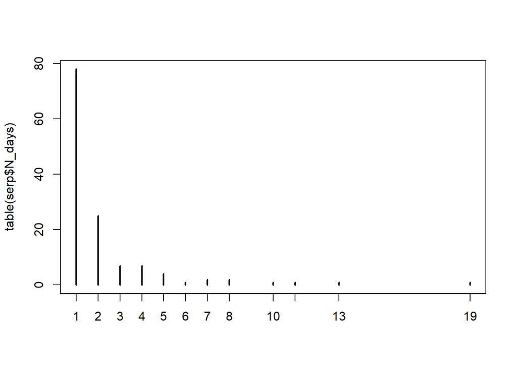

```r
plot(table(serp$N_days))
```

```r
mean(serp$N_days)
```

```
## [1] 2.2
```

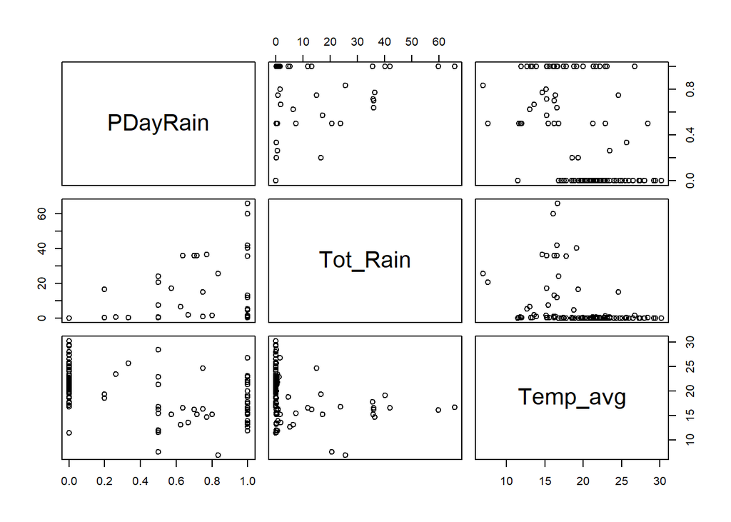

```r
pairs(serp[, c("PDayRain", "Tot_Rain", "Temp_avg")])
```

```r
round(cor(serp[, c("PDayRain", "Tot_Rain", "Temp_avg")]), 2)
```

```
##          PDayRain Tot_Rain Temp_avg
## PDayRain     1.00     0.42     -0.5
## Tot_Rain     0.42     1.00     -0.3
## Temp_avg    -0.50    -0.30      1.0
```

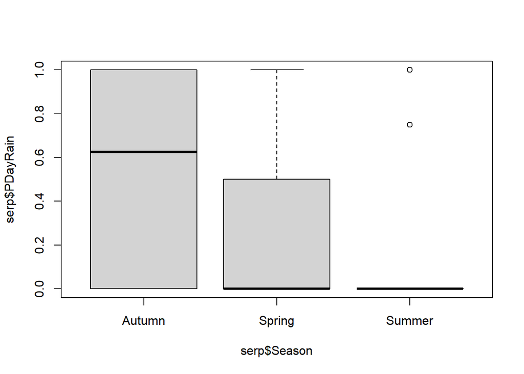

```r
boxplot(serp$PDayRain ~ serp$Season)
```

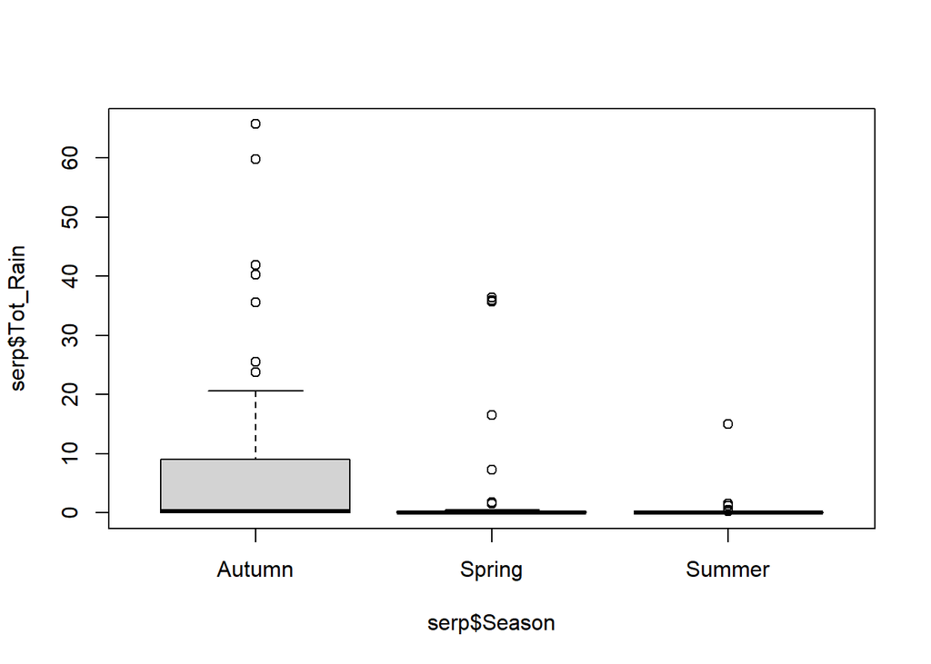

```r
boxplot(serp$Tot_Rain ~ serp$Season)
```

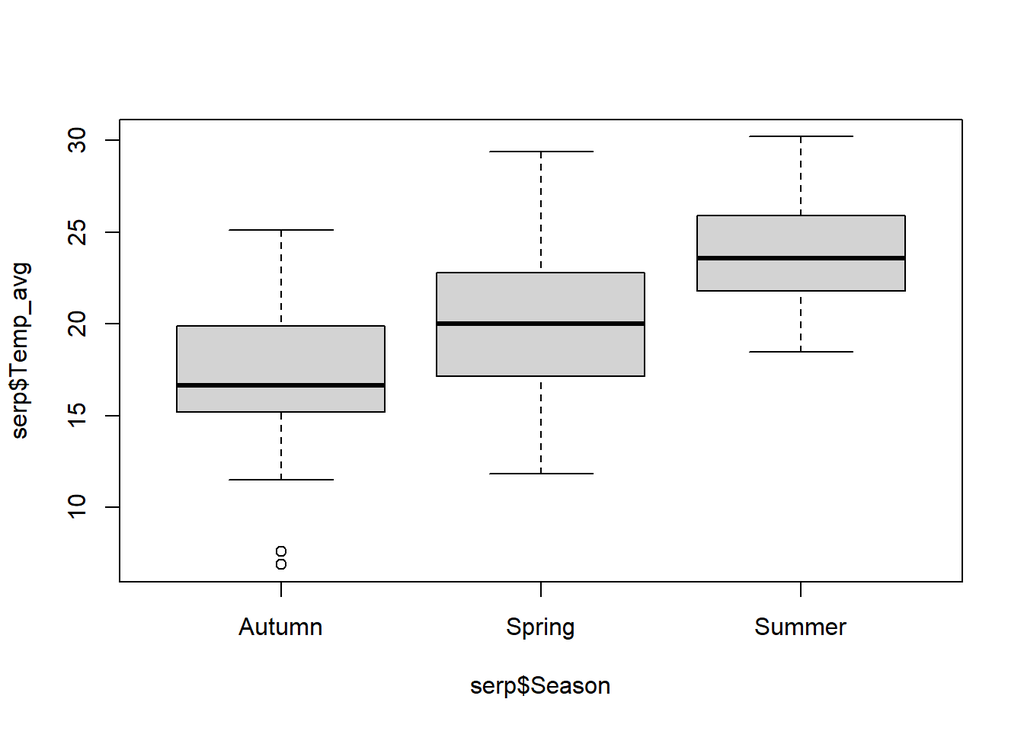

```r
boxplot(serp$Temp_avg ~ serp$Season)
```

### GLM Poisson

```r
m.pois <- glm(N_days ~ Size_cm + PDayRain + Tot_Rain + Road + Size_cm + Road_Loc + Size_cm:PDayRain, family = poisson, data = serp)
summary(m.pois)
```

```
##
## Call:
## glm(formula = N_days ~ Size_cm + PDayRain + Tot_Rain + Road +
##     Size_cm + Road_Loc + Size_cm:PDayRain, family = poisson,
##     data = serp)
##
## Deviance Residuals:
##     Min       1Q   Median       3Q      Max
## -2.0869  -0.7901  -0.4193   0.2448   5.9495
##
## Coefficients:
##                    Estimate Std. Error z value Pr(>|z|)
## (Intercept)       -0.114527   0.463263  -0.247 0.804739
## Size_cm            0.004782   0.002965   1.613 0.106848
## PDayRain           0.957714   0.768545   1.246 0.212713
## Tot_Rain           0.022763   0.003797   5.994 2.04e-09 ***
## RoadEN370_EN114_4 -0.146154   0.172785  -0.846 0.397626
## RoadEN4           -0.352271   0.147973  -2.381 0.017282 *
## Road_LocV          0.530610   0.158214   3.354 0.000797 ***
## Size_cm:PDayRain  -0.006869   0.005161  -1.331 0.183215
## ---
## Signif. codes:  0 '***' 0.001 '**' 0.01 '*' 0.05 '.' 0.1 ' ' 1
##
## (Dispersion parameter for poisson family taken to be 1)
##
##     Null deviance: 226.38  on 129  degrees of freedom
## Residual deviance: 166.85  on 122  degrees of freedom
## AIC: 498.68
##
## Number of Fisher Scoring iterations: 5
```

### GLM Poisson truncado en cero

```r
library(VGAM)
m.pois.trun <- vglm(N_days ~ Size_cm + PDayRain + Tot_Rain + Road + Size_cm + Road_Loc + Size_cm:PDayRain, family = pospoisson, control =  vglm.control(maxit = 100), data = serp)
summary(m.pois.trun)
```

```
##
## Call:
## vglm(formula = N_days ~ Size_cm + PDayRain + Tot_Rain + Road +
##     Size_cm + Road_Loc + Size_cm:PDayRain, family = pospoisson,
##     data = serp, control = vglm.control(maxit = 100))
##
## Coefficients:
##                    Estimate Std. Error z value Pr(>|z|)
## (Intercept)       -1.214880   0.764099  -1.590  0.11185
## Size_cm            0.009725   0.004830   2.014  0.04406 *
## PDayRain           1.782494   1.097674   1.624  0.10440
## Tot_Rain           0.028863   0.004270   6.760 1.38e-11 ***
## RoadEN370_EN114_4 -0.217333   0.225081  -0.966  0.33425
## RoadEN4           -0.558705   0.181936  -3.071  0.00213 **
## Road_LocV          0.811896   0.200842   4.042 5.29e-05 ***
## Size_cm:PDayRain  -0.012131   0.007245  -1.674  0.09404 .
## ---
## Signif. codes:  0 '***' 0.001 '**' 0.01 '*' 0.05 '.' 0.1 ' ' 1
##
## Name of linear predictor: loglink(lambda)
##
## Log-likelihood: -211.1832 on 122 degrees of freedom
##
## Number of Fisher scoring iterations: 5
##
## No Hauck-Donner effect found in any of the estimates
```

### GLM binomial negativo truncado en cero

```r
m.nb.trun <- vglm(N_days ~ Size_cm + PDayRain + Tot_Rain + Road + Size_cm + Road_Loc + Size_cm:PDayRain, family = posnegbinomial, control =  vglm.control(maxit = 100), data = serp)
summary(m.nb.trun)
```

```
##
## Call:
## vglm(formula = N_days ~ Size_cm + PDayRain + Tot_Rain + Road +
##     Size_cm + Road_Loc + Size_cm:PDayRain, family = posnegbinomial,
##     data = serp, control = vglm.control(maxit = 100))
##
## Coefficients:
##                     Estimate Std. Error  z value Pr(>|z|)
## (Intercept):1     -18.650956   9.622924       NA       NA
## (Intercept):2     -19.201942   0.087878 -218.508   <2e-16 ***
## Size_cm             0.006975   0.062006    0.112    0.910
## PDayRain            1.196235  18.692101    0.064    0.949
## Tot_Rain            0.067164   0.117128    0.573    0.566
## RoadEN370_EN114_4  -0.276550   4.059935   -0.068    0.946
## RoadEN4            -0.558499   3.643634   -0.153    0.878
## Road_LocV           1.072722   3.817984    0.281    0.779
## Size_cm:PDayRain   -0.009605   0.126436   -0.076    0.939
## ---
## Signif. codes:  0 '***' 0.001 '**' 0.01 '*' 0.05 '.' 0.1 ' ' 1
##
## Names of linear predictors: loglink(munb), loglink(size)
##
## Log-likelihood: -186.7285 on 251 degrees of freedom
##
## Number of Fisher scoring iterations: 3
##
## Warning: Hauck-Donner effect detected in the following estimate(s):
## '(Intercept):1'
```

### Comparacion de coeficientes entre modelos

```r
data.frame(coef.Poisson = summary(m.pois)$coeff[, 1],
           coef.Poisson.truncado = summary(m.pois.trun)@coef3[, 1])
```

```
##                   coef.Poisson coef.Poisson.truncado
## (Intercept)       -0.114527460          -1.214879652
## Size_cm            0.004781715           0.009724801
## PDayRain           0.957714141           1.782494406
## Tot_Rain           0.022763117           0.028863331
## RoadEN370_EN114_4 -0.146153654          -0.217333044
## RoadEN4           -0.352270790          -0.558704924
## Road_LocV          0.530609962           0.811896312
## Size_cm:PDayRain  -0.006868709          -0.012131485
```

## Modelos inflados en ceros

```r
# Analisis exploratorio
parasitos <- read.table("C:/RD/ParasiteCod.txt", header = T)
str(parasitos)
```

```
## 'data.frame':    1254 obs. of  11 variables:
##  $ Sample    : int  1 2 3 4 5 6 7 8 9 10 ...
##  $ Intensity : int  0 0 0 0 0 0 0 0 0 0 ...
##  $ Prevalence: int  0 0 0 0 0 0 0 0 0 0 ...
##  $ Year      : int  1999 1999 1999 1999 1999 1999 1999 1999 1999 1999 ...
##  $ Depth     : int  220 220 220 220 220 220 220 194 194 194 ...
##  $ Weight    : int  148 144 146 138 40 68 52 3848 2576 1972 ...
##  $ Length    : int  26 26 27 26 17 20 19 77 67 60 ...
##  $ Sex       : int  0 0 0 0 0 0 0 0 0 0 ...
##  $ Stage     : int  0 0 0 0 0 0 0 0 0 0 ...
##  $ Age       : int  0 0 0 0 0 0 0 0 0 0 ...
##  $ Area      : int  2 2 2 2 2 2 2 3 3 3 ...
```

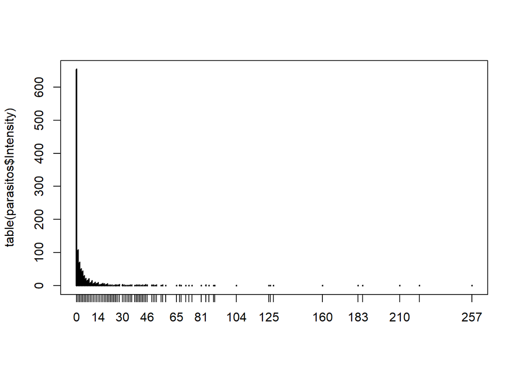

```r
plot(table(parasitos$Intensity))
```

```r
table(parasitos$Intensity)[1] # Numero de ceros observados
```

```
##   0
## 654
```

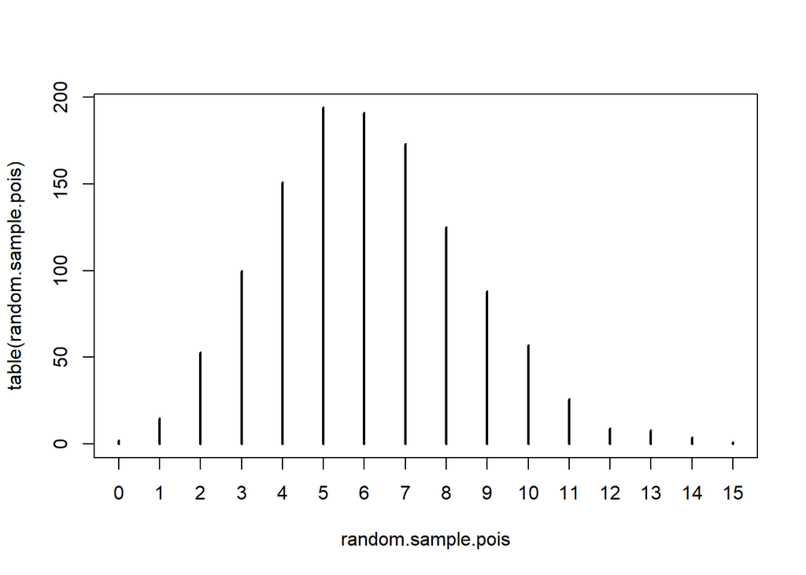

```r
# Ajuste de distribucion a los datos
xIntensity <- mean(parasitos$Intensity, na.rm = TRUE)
sim.pois <- dpois(x = 0:max(parasitos$Intensity, na.rm = TRUE), lambda = xIntensity)
ndatos <- length(na.omit(parasitos$Intensity))
random.sample.pois <- rpois(n = ndatos, lambda = xIntensity)
plot(table(random.sample.pois))
```

```r
exp(-xIntensity) # Probabilidad de observar un cero
```

```
## [1] 0.002064314
```

```r
length(random.sample.pois[random.sample.pois == 0]) # Numero de ceros esperados
```

```
## [1] 2
```

### GLMs inflados en ceros (ZIP y ZINB)

```r
library(pscl)
# La primera parte de la formula contiene las covariables para el proceso de conteo, la segunda parte contiene las covariables para la probabilidad de los falsos ceros.
ZIP <- zeroinfl(Intensity ~ Depth | Length + Depth, dist = "poisson",
link = "logit", data = parasitos)
summary(ZIP)
```

```
##
## Call:
## zeroinfl(formula = Intensity ~ Depth | Length + Depth, data = parasitos,
##     dist = "poisson", link = "logit")
##
## Pearson residuals:
##     Min      1Q  Median      3Q     Max
## -1.3420 -0.8995 -0.6450 -0.2622 32.6703
##
## Count model coefficients (poisson with log link):
##              Estimate Std. Error z value Pr(>|z|)
## (Intercept) 1.7740079  0.0412533   43.00   <2e-16 ***
## Depth       0.0041351  0.0001857   22.27   <2e-16 ***
##
## Zero-inflation model coefficients (binomial with logit link):
##               Estimate Std. Error z value Pr(>|z|)
## (Intercept)  1.6523797  0.2870373   5.757 8.58e-09 ***
## Length      -0.0039426  0.0042167  -0.935     0.35
## Depth       -0.0070509  0.0008585  -8.213  < 2e-16 ***
## ---
## Signif. codes:  0 '***' 0.001 '**' 0.01 '*' 0.05 '.' 0.1 ' ' 1
##
## Number of iterations in BFGS optimization: 1
## Log-likelihood: -8542 on 5 Df
```

```r
ZINB <- zeroinfl(Intensity ~ Depth | Length + Depth, dist = "negbin",
link = "logit", data = parasitos)
summary(ZINB)
```

```
##
## Call:
## zeroinfl(formula = Intensity ~ Depth | Length + Depth, data = parasitos,
##     dist = "negbin", link = "logit")
##
## Pearson residuals:
##      Min       1Q   Median       3Q      Max
## -0.45165 -0.44692 -0.33559 -0.07448 15.18154
##
## Count model coefficients (negbin with log link):
##              Estimate Std. Error z value Pr(>|z|)
## (Intercept)  0.868040   0.252504   3.438 0.000587 ***
## Depth        0.005512   0.001216   4.534  5.8e-06 ***
## Log(theta)  -1.572514   0.058398 -26.927  < 2e-16 ***
##
## Zero-inflation model coefficients (binomial with logit link):
##             Estimate Std. Error z value Pr(>|z|)
## (Intercept)  6.25506    1.36666   4.577 4.72e-06 ***
## Length       0.03373    0.02168   1.556     0.12
## Depth       -0.08659    0.01519  -5.699 1.21e-08 ***
## ---
## Signif. codes:  0 '***' 0.001 '**' 0.01 '*' 0.05 '.' 0.1 ' ' 1
##
## Theta = 0.2075
## Number of iterations in BFGS optimization: 26
## Log-likelihood: -2537 on 6 Df
```

### Comparacion de ZIP y ZINB

```r
library(lmtest)
lrtest(ZIP, ZINB) # Test de razon de verosimilitud
```

```
## Likelihood ratio test
##
## Model 1: Intensity ~ Depth | Length + Depth
## Model 2: Intensity ~ Depth | Length + Depth
##   #Df  LogLik Df Chisq Pr(>Chisq)
## 1   5 -8542.3
## 2   6 -2537.5  1 12010  < 2.2e-16 ***
## ---
## Signif. codes:  0 '***' 0.001 '**' 0.01 '*' 0.05 '.' 0.1 ' ' 1
```

### Validacion

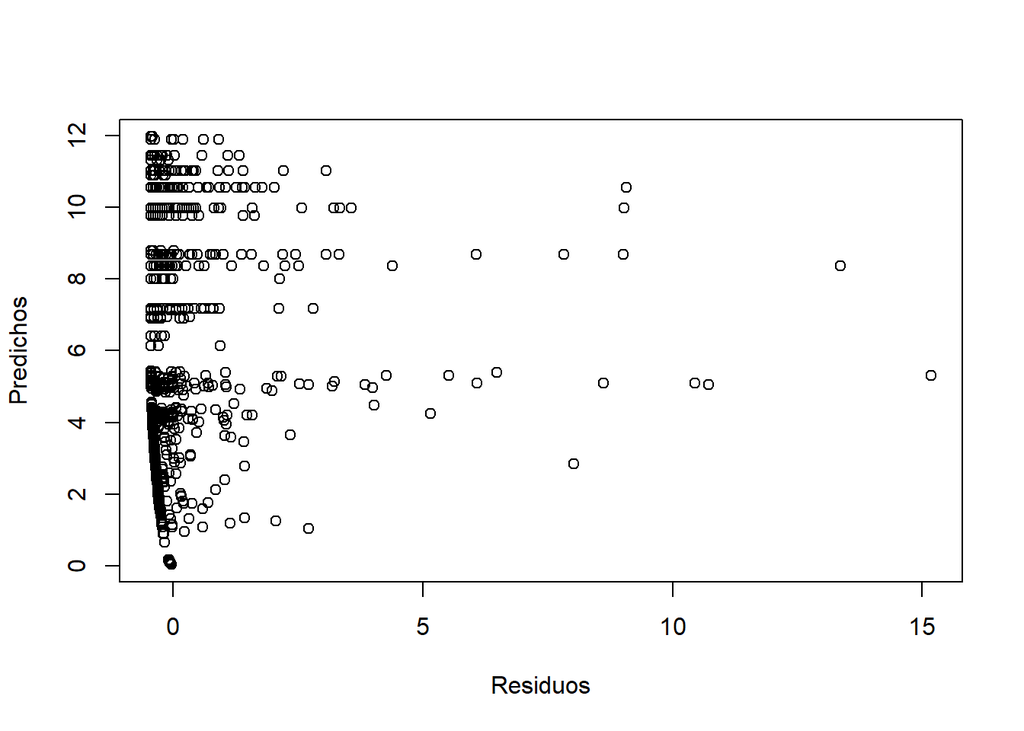

```r
resid <- residuals(ZINB, type = "pearson")
plot(resid, predict(ZINB), xlab = "Residuos", ylab = "Predichos")
```

```r
AIC(ZIP, ZINB)
```

```
##      df       AIC
## ZIP   5 17094.549
## ZINB  6  5086.954
```

### Interpretacion y graficos del modelo

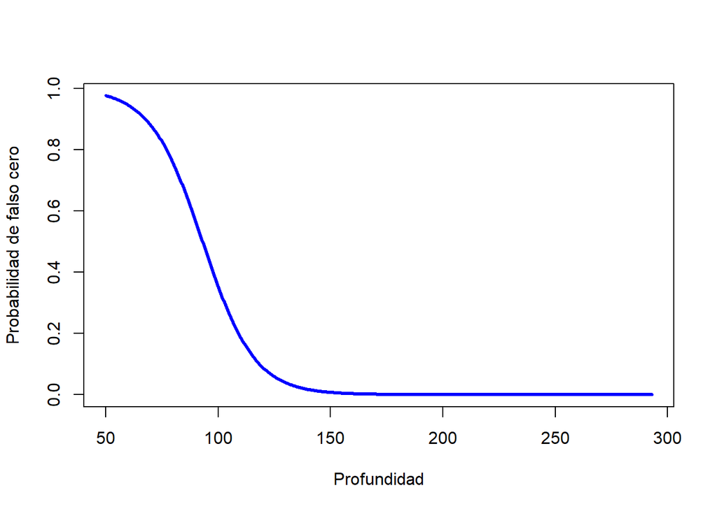

```r
# Proceso de falsos ceros
Depth <- seq(min(parasitos$Depth), max(parasitos$Depth), length = 500)
Length <- mean(parasitos$Length, na.rm = TRUE)
zero.model.coef <- ZINB$coefficients$zero # Coeficientes
u <- zero.model.coef[1] + Length*zero.model.coef[2] + Depth*zero.model.coef[3]
zero.model.pred <- exp(u)/(1 + exp(u)) # Predicciones
plot(Depth, zero.model.pred, col = "blue", type = "l", lwd = 3, xlab = "Profundidad", ylab = "Probabilidad de falso cero")
```

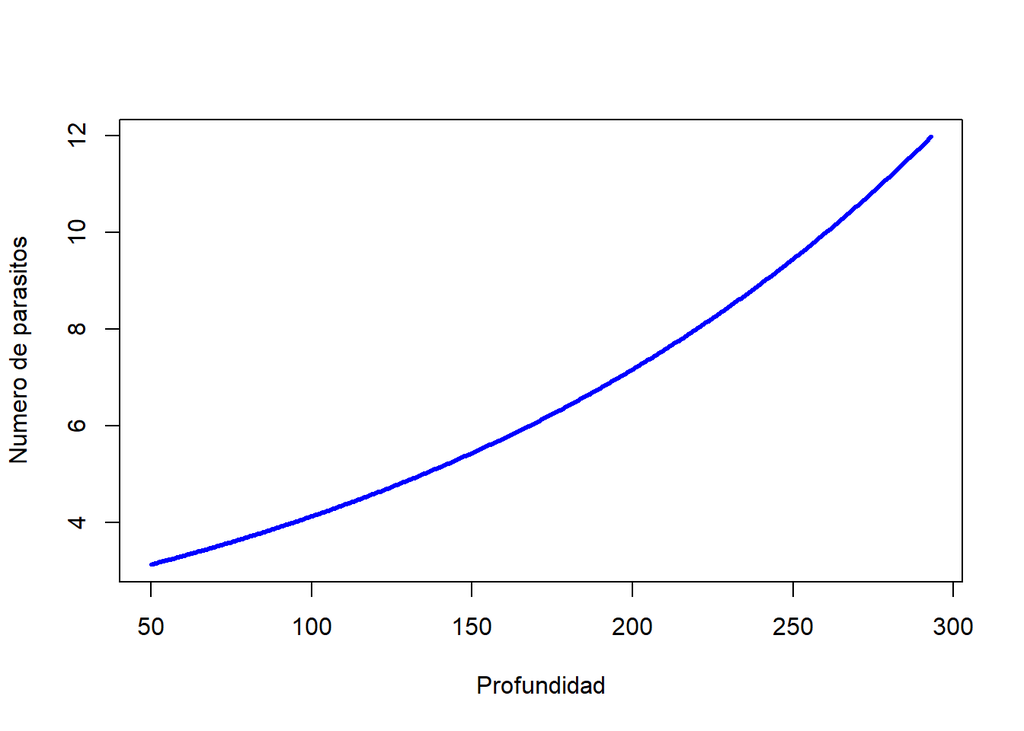

```r
# Proceso de conteo
count.model.coef <- ZINB$coefficients$count # Coeficientes
u <- count.model.coef[1] + Depth*count.model.coef[2]
count.model.pred <- exp(u) # Predicciones
plot(Depth, count.model.pred, col = "blue", type = "l", lwd = 3, xlab = "Profundidad", ylab = "Numero de parasitos")
```

### Modelos alterados en ceros (ZAP y ZANB)

```r
# La primera parte de la formula contiene las covariables para el proceso de conteo, la segunda parte contiene las covariables para la probabilidad de los falsos ceros.
ZAP <- hurdle(Intensity ~ Depth | Length + Depth, dist = "poisson",
link = "logit", data = parasitos)
summary(ZAP)
```

```
##
## Call:
## hurdle(formula = Intensity ~ Depth | Length + Depth, data = parasitos,
##     dist = "poisson", link = "logit")
##
## Pearson residuals:
##     Min      1Q  Median      3Q     Max
## -1.3420 -0.8995 -0.6450 -0.2622 32.6701
##
## Count model coefficients (truncated poisson with log link):
##              Estimate Std. Error z value Pr(>|z|)
## (Intercept) 1.7740079  0.0412390   43.02   <2e-16 ***
## Depth       0.0041351  0.0001857   22.27   <2e-16 ***
## Zero hurdle model coefficients (binomial with logit link):
##               Estimate Std. Error z value Pr(>|z|)
## (Intercept) -1.6523797  0.2870146  -5.757 8.56e-09 ***
## Length       0.0039426  0.0042165   0.935     0.35
## Depth        0.0070509  0.0008584   8.214  < 2e-16 ***
## ---
## Signif. codes:  0 '***' 0.001 '**' 0.01 '*' 0.05 '.' 0.1 ' ' 1
##
## Number of iterations in BFGS optimization: 10
## Log-likelihood: -8542 on 5 Df
```

```r
ZANB <- hurdle(Intensity ~ Depth | Length + Depth, dist = "negbin",
link = "logit", data = parasitos)
summary(ZANB)
```

```
##
## Call:
## hurdle(formula = Intensity ~ Depth | Length + Depth, data = parasitos,
##     dist = "negbin", link = "logit")
##
## Pearson residuals:
##     Min      1Q  Median      3Q     Max
## -0.4350 -0.3729 -0.3281 -0.1126 16.3175
##
## Count model coefficients (truncated negbin with log link):
##              Estimate Std. Error z value Pr(>|z|)
## (Intercept) -0.415345   0.844211  -0.492 0.622725
## Depth        0.006271   0.001537   4.080 4.51e-05 ***
## Log(theta)  -3.019216   0.867902  -3.479 0.000504 ***
## Zero hurdle model coefficients (binomial with logit link):
##               Estimate Std. Error z value Pr(>|z|)
## (Intercept) -1.6523797  0.2870146  -5.757 8.56e-09 ***
## Length       0.0039426  0.0042165   0.935     0.35
## Depth        0.0070509  0.0008584   8.214  < 2e-16 ***
## ---
## Signif. codes:  0 '***' 0.001 '**' 0.01 '*' 0.05 '.' 0.1 ' ' 1
##
## Theta: count = 0.0488
## Number of iterations in BFGS optimization: 16
## Log-likelihood: -2559 on 6 Df
```

### Comparacion de ZAP y ZANB

```r
library(lmtest)
lrtest(ZAP, ZANB) # Test de razon de verosimilitud
```

```
## Likelihood ratio test
##
## Model 1: Intensity ~ Depth | Length + Depth
## Model 2: Intensity ~ Depth | Length + Depth
##   #Df  LogLik Df Chisq Pr(>Chisq)
## 1   5 -8542.3
## 2   6 -2559.4  1 11966  < 2.2e-16 ***
## ---
## Signif. codes:  0 '***' 0.001 '**' 0.01 '*' 0.05 '.' 0.1 ' ' 1
```

```r
AIC(ZAP, ZANB)
```

```
##      df      AIC
## ZAP   5 17094.58
## ZANB  6  5130.85
```

### Validacion

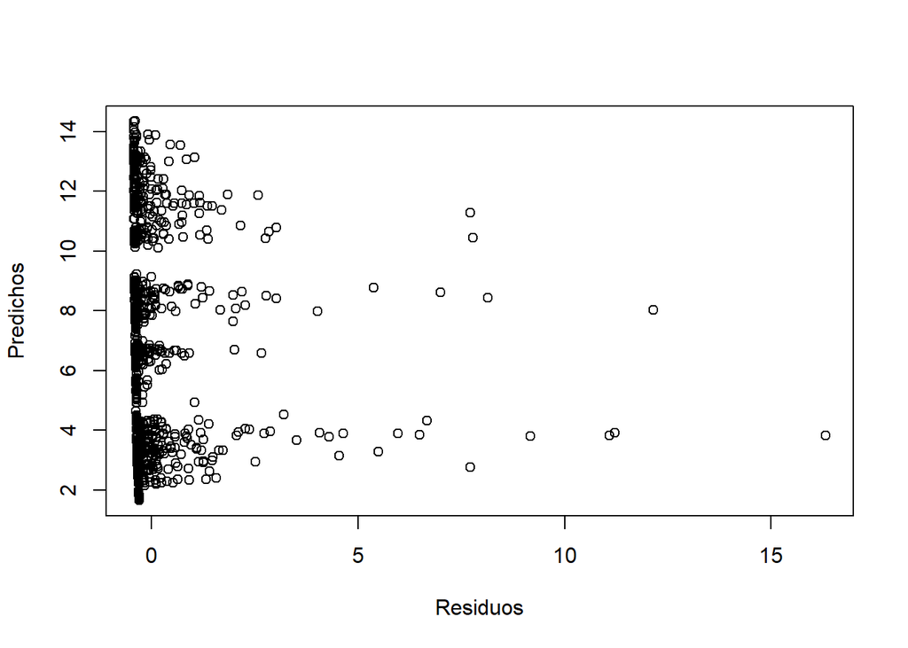

```r
resid <- residuals(ZANB, type = "pearson")
plot(resid, predict(ZANB), xlab = "Residuos", ylab = "Predichos")
```

### Interpretacion y graficos del modelo

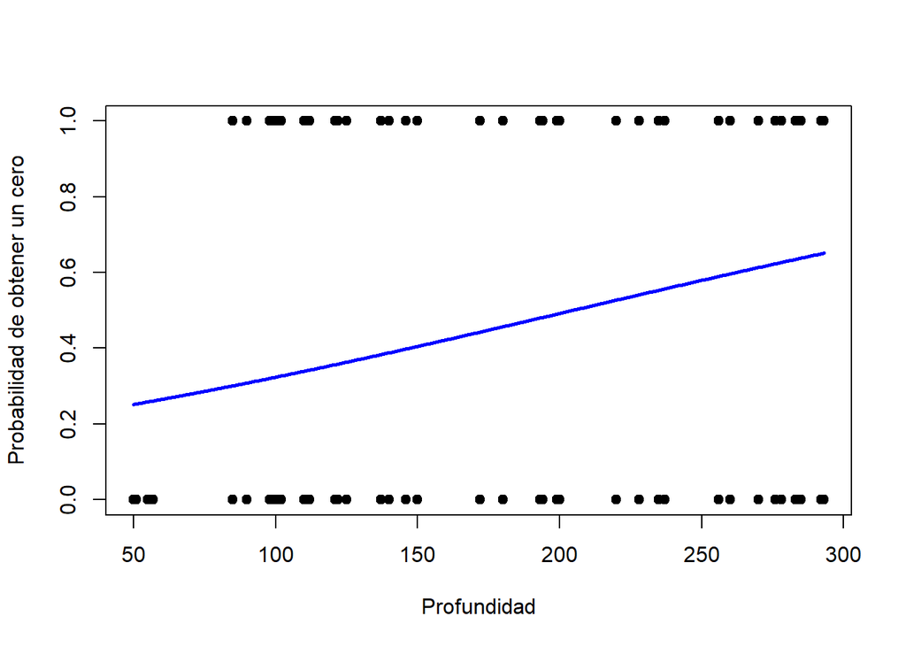

```r
# Proceso de falsos ceros
Depth <- seq(min(parasitos$Depth), max(parasitos$Depth), length = 500)
Length <- mean(parasitos$Length, na.rm = TRUE)
zero.model.coef <- ZANB$coefficients$zero # Coeficientes
u <- zero.model.coef[1] + Length*zero.model.coef[2] + Depth*zero.model.coef[3]
zero.model.pred <- exp(u)/(1 + exp(u)) # Predicciones
parasitos$ceros <- ifelse(parasitos$Intensity == 0, 0, 1) # Ceros vs no ceros
plot(parasitos$Depth, parasitos$ceros, pch = 19, xlab = "Profundidad", ylab = "Probabilidad de obtener un cero")
lines(Depth, zero.model.pred, col = "blue", lwd = 2.5, main = "ZANB")
```

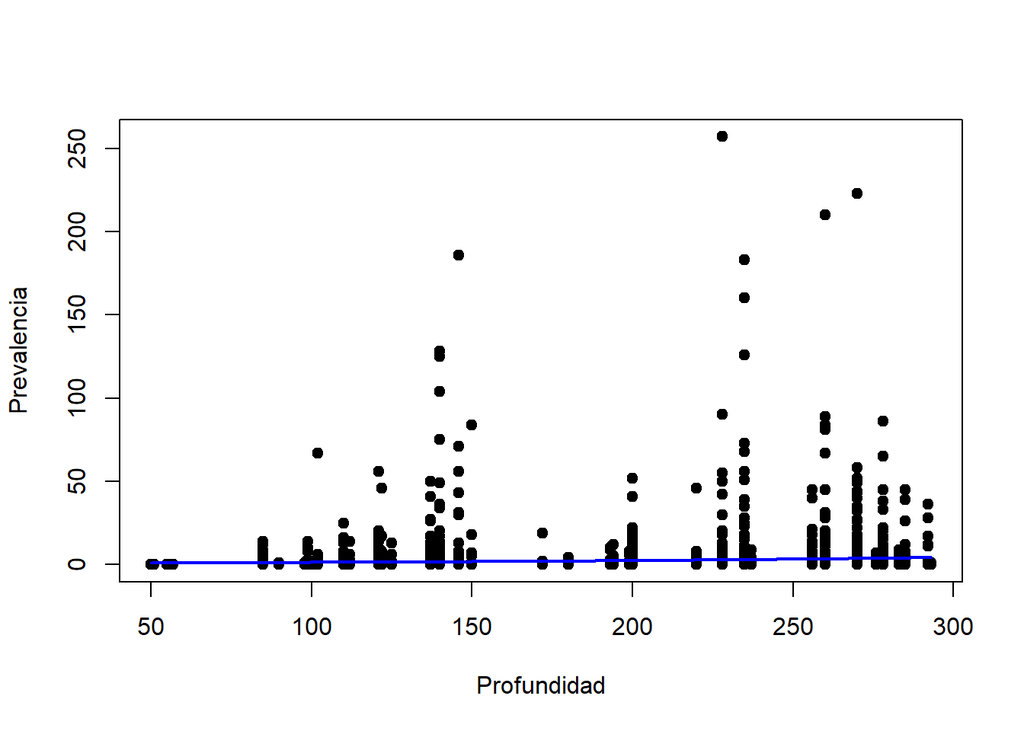

```r
# Proceso de conteo
count.model.coef <- ZANB$coefficients$count # Coeficientes
u <- count.model.coef[1] + Depth*count.model.coef[2]
count.model.pred <- exp(u) # Predicciones
plot(parasitos$Depth, parasitos$Intensity, pch = 19, xlab = "Profundidad", ylab = "Prevalencia")
lines(Depth, count.model.pred, col = "blue", lwd = 2)
```